# Krzywe pościgowe i ich wykorzystania

### 1. Wstęp

Krzywa pościgowa, inaczej zwana też krzywą pogoni, to droga, którą obiekt podąża podczas ścigania innego obiektu. Problem pierwszy raz został podjęty przez Leonadro da Vinci'ego (1452-1519), który rozważał sytację, w której ścigany porusza po lini prostej. Ogólne zagadnienie było rozpatrywane w 1732 przez francuza Pierre'a Bouguera (1698-1758). Analizował on krzywą, po której porusza się statek piracki ścigający łódź kupiecką zakładając, że ich prędkości mają stałą proporcje [1].

Termin „krzywe pościgowe” został jednak zdefiniowany dopiero w 1859 przez Geogrge'a Boole'a (1815-1864) w *Treatise on differential equations* [2]. Zdefiniował je jako "droga, którą nakreśla punkt poruszający się z jednostajną prędkością w kierunku innego punktu, który porusza się z jednostajną prędkością po danej krzywej". Boole w swojej analizie zajmował się ruchem tylko w dwóch wymiarach.

Krzywe te są często wykorzystywane w badaniach wojskowych. Droga myśliwca, który probuje wystrzelić rakiete w poruszający się cel i który cały czas leci w kierunku tego celu to właśnie krzywa pogoni.

### 2. Model, w którym „uciekający” porusza się po lini prostej z danymi warunkami brzegowymi

#### A. Wyprowadzenie analityczne równania [3]

Niech $A$ będzie punktem odpowiadającym pozycji „uciekającego”, a $B$ punktem odpowiadającym pozycji „ścigającego”. $A$ poruszaj się ruchem jednostajnym z stałą prędkością $v$, a punkt $B$ z prędkością $w$, której wekotr jest zawsze skierowany w kierunku $A$. Niech $k=\frac{v}{w}$.

Rozwiązanie równania w kartezjańskim ukladzie współrzędnych dla nastepująych warunków początkowych:

- $A$ zaczyna w pozycji $A_0=(0,0)$ oraz porusza się wzdłuż osi $OY$
- $B$ zaczyna w pozucji $B_0=(1,0)$

Wiemy, że „uciekający” przemieszcza się na stycznej do toru „ściganego”, zatem mamy równanie $$\frac{\mathrm{d} x}{\mathrm{d} y}=\frac{-x}{s-y},$$ gdzie $s$ to droga przebyta przez punkt $A$, czyli $s=vt$.

Uproszczamy wyrażnie i dostajemy $$x'(s-y)=-x,$$ gdzie $x>0$.

Podstawiamy $s=vt$ $$x+x'vt-x'y=0.$$

Następnie po pomnożeniu stronami przez $\frac{1}{x'}$ oraz dodaniu $y$ uzyskujemy $$\frac{x}{x'}+vt=y.$$

Różniczkujemy powyższe równanie po $y$, żeby uzyskać $$y'=\frac{\mathrm{d}y}{\mathrm{d}t}=\frac{v\cdot x'^2}{x\cdot x''}.$$

Będziemy korzystać z poniższego wzoru na długość łuku $$l=wt=k\int_0^y\sqrt{1+(x')^2}\mathrm{d}y.$$

Z $x'^2+y'^2=w^2\mathrm{d}t^2$ wynika, że $$y'=\frac{w}{\sqrt{1+x^2}}.$$

Następnie wykonujemy różczniczkowanie po $x$: $$x''-k\cdot \frac{x'^2}{x} \cdot \sqrt{1+x'^2}=0.$$

Będziemy teraz stosować poniższe podstawienie $$u=y'=\frac{1}{x'}, \quad x''=\frac{-1}{u^3}\cdot \frac{\mathrm{d}u}{\mathrm{d}x}.$$

Po wstawieniu otrzymujemy $$\frac{-1}{u^3}\cdot\frac{\mathrm{d}u}{\mathrm{d}x} - k \cdot \frac{1}{u^2\cdot x} \cdot \sqrt{1+\frac{1}{u^2}}=0.$$

Po uproszczeniu dostajemy $$-k\cdot\frac{1}{u^3\cdot x}\sqrt{u^2+1}=\frac{1}{u^3}\cdot\frac{\mathrm{d}u}{\mathrm{d}x},$$

co po dalszych trywialnych przekształceniach daje nam $$\frac{-\mathrm{d}u}{\sqrt{1+u^2}}=k\cdot \frac{\mathrm{d}x}{x}.$$

Scałkowanie powyższego równania pozwala nam uzyskać $$\text{arsinh }u=k\cdot \ln{x}+C,$$ gdzie $C$ to stała całkowania.

Podstawiając z powrotem $y$ do równania dostajemy $$ \sinh^-1{y'}=k\cdot \ln{x} +C,$$

co jest równoważne z $$y'=\sinh(k\cdot\ln{x}+C).$$

Teraz skorzystajmy z defnicji $\sinh$, żeby przekształcic lewą stronę wydarzenia $$ y'= \displaystyle\frac{e^{k\cdot\ln{x}+C}-e^{-k\cdot\ln{x}+C}}{2}=\frac{1}{2}\left(x^k\cdot x^C-x^{-k}\cdot e^C\right).$$

Przyjmijmy, że $D_1=e^C$, wtedy równanie przyjmuje nastepującą postać $$y'=\frac{1}{2}(D_1\cdot x^k-D_1\cdot x^{-k}).$$

Z pierwszego warunku brzgowego $y'(1)=0$ otrzymujemy $$ 0=\frac{1}{2}(D_1-D_1),$$ zatem $D_1=1$ i można zpisać dokładną forme naszego równania $$ y' = \frac{\mathrm{d}y}{\mathrm{d}x} = \frac{1}{2}(x^k-x^{-k}).$$

Całkujemy powyższe wyrażenie i otrzymujemy $$y=\frac{1}{2}\left(\frac{x^{k+1}}{k+1} + \frac{x^{1-k}}{k-1} \right)+D_2$$

Korzystając z drugiego warunku brzegowego $y(1)=0$ dostajemy $$ 0 = \frac{1}{2}\left(\frac{1}{k+1}+\frac{1}{k-1}\right)+D_2, $$ uproszczając możemy zapisać $$ D_2 = - \frac{1}{2} (\frac{2k}{(k+1)(k-1)}). $$

Dostajemy $$C_2=\frac{k}{1-k^2}, $$ w szególności mamy $$C_2=-\frac{1}{4},$$ dla $k=1.$

Ostatecznie otrzymujemy $$y(x)=\frac{1}{2}\left(\frac{x^{(1+k)}}{1+k}-\frac{x^{(1-k)}}{1+k}\right)+\frac{k}{1-k^2} \text{ dla }k\neq 1 \\ y(x)=\frac{1}{2}\left(\frac{x^{2}}{2}-\ln{|x|}\right)-\frac{1}{4} \text{ dla } k=1 $$

#### B. Implementacja równania otrzymanego analitycznie

```python
import matplotlib.pyplot as plt
import numpy as np
```

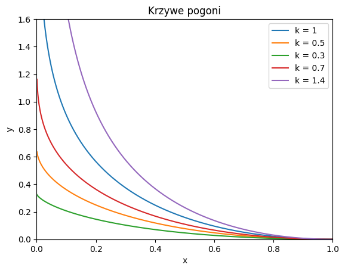

```python
def curve_method_1(k):
    xs = np.arange(0.001,1,0.001)
    if k==1:
        ys=0.25*(xs**2-np.log(xs**2)-1)
    else:
        ys = 0.5*((1-xs**(1-k))/(1-k)-(1-xs**(k+1))/(k+1))
    name = f"k = {k}"
    plt.plot(xs,ys,label=name)
    return ys

curve_method_1(1)
curve_method_1(0.5)
curve_method_1(0.3)
curve_method_1(0.7)
curve_method_1(1.4)


plt.xlim([0,1])
plt.ylim([0,1.6])
plt.xlabel("x")
plt.ylabel("y")
plt.title("Krzywe pogoni")

plt.legend()
plt.show()
```

#### C. Implementacja numeryczna - zastosowanie metody Eulera

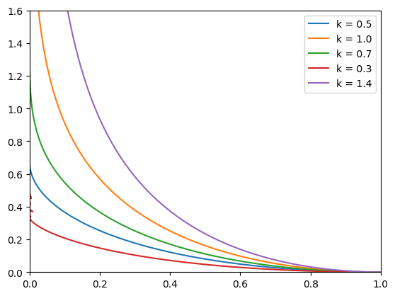

```python
def curve_method_2(v,w):
    t=0
    x=[1]
    y=[0]
    h=0.01
    for i in range(10000):
        t+=0.01
        y.append(y[i]+h*v*(w*t-y[i])/(np.sqrt((x[i])**2+(w*t-y[i])**2)))
        x.append(x[i]+h*v*(-x[i])/(np.sqrt((x[i])**2+(w*t-y[i])**2)))
    name = f"k = {w/v}"
    plt.plot(x,y,label=name)
    return x,y

curve_method_2(2,1)
curve_method_2(1,1)
curve_method_2(1,0.7)
curve_method_2(1,0.3)
curve_method_2(1,1.4)


plt.xlim([0,1])
plt.ylim([0,1.6])
plt.legend()
plt.show()
```

#### D. Porównanie metody analitycznej z numeryczną

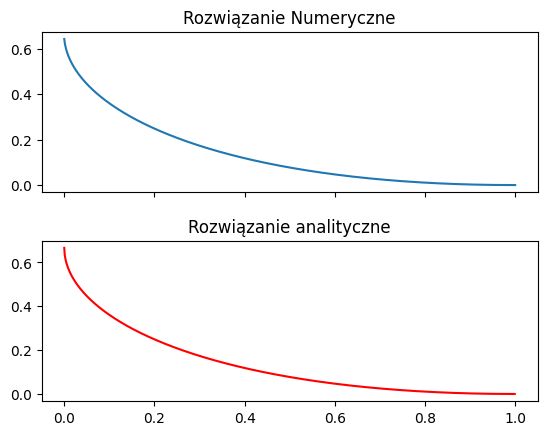

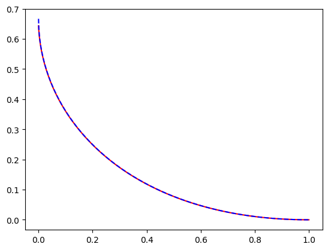

```python
y=[0]
x=[1]
h=0.001

for i in range(1000):
    y.append(y[i]-h*0.5*((x[i]**(0.5))-((1/x[i])**0.5)))
    x.append(x[i]-h)
fig = plt.figure()
gs=fig.add_gridspec(2,1,hspace=0.3)
axs1,axs2=gs.subplots(sharex='col',sharey='row')
axs1.set_title("Rozwiązanie Numeryczne")
axs1.plot(x,y)
X=np.arange(0,1,0.001)
y_an=0.5*(((X**1.5)/1.5)-((X**0.5)/(0.5)))+(2/3)
axs2.set_title("Rozwiązanie analityczne")
axs2.plot(X,y_an,color="red")
plt.show()

plt.plot(x,y,color="red")
plt.plot(X,y_an,color="blue",linestyle='--')
plt.show()
```

### 3. Ogólne wyprowadzenie wzoru na krzywą pościgową

#### A. Wyprowadzenie analityczne równania ogólnego [4]

Niech pozycja „uciekającego” będzie funkcją parametryczną $\mathbf{R}(t)$ oraz pozycja „ścigąjącego” będzie dana jako $\mathbf{F}(t)=\langle x(t), y(t) \rangle$. Tak jak wcześniej przyjmujemy, że „uciekający” poruszaj się ze stałą prędkością $v$, a „uciekający” z prędkością $w$, której wekotr jest zawsze skierowany w kierunku „uciekającego” oraz $k=\frac{v}{w}$.

Z definicji krzywej pościgowe jasnym jest, że jednostkowy wektor styczny do krzywej, po której porusza się „ścigający” to $$ \frac{\mathbf{F'}}{\|\mathbf{F'}\|} = \frac{\mathbf{R}-\mathbf{F}}{\|\mathbf{R}-\mathbf{F}\|}.$$

Z definicji $k$, wynika $$\|\mathbf{F'}\| = k \|\mathbf{R'}\|,$$ podstawiając to teraz do równania wyżej otrzymujemy ogólne równanie różniczkowe opisujące krzywą pogoni $$ \mathbf{F'}=k \|\mathbf{R'}\| \frac{\mathbf{R}-\mathbf{F}}{\|\mathbf{R}-\mathbf{F}\|}. $$

To nieliniowe równanie rożniczkowe rozwiązuje się w dużej ilości przypadków po przez rozwiązania numeryczne. Istnieje jednak klika przypadków specjalnych, w których da się rozwiązać równanie analitycznie.

#### B. Model zakładający, że tor „uciekającego” to linia prosta [4]

Bez starty ogólności można przyjąć, że „uciekający” porusza się wzdłuż osi $Y$ oraz można sparametryzować jego drogę przez $\mathbf{R}(t)=\langle 0, rt \rangle$. Przyjmijmując, że początkowa pozycja „ścigającego” jest dana jako $\mathbf{F}(0)=\langle c,0 \rangle$, gdzie $c$ to dodatnia stała. Różniczkowe równanie wektorowe punktu „ścigającego” można wtedy uprościć do naspeującego układu $$ \begin{cases} x'=-\frac{krx}{\sqrt{x^2+(rt-y)^2}} \\ y'=\frac{kr(rt-y)}{\sqrt{x^2+(rt-y+^2)}} \end{cases} $$

Z reguły łańcucha dostajemy $$\frac{\mathrm{d}y}{\mathrm{d}x}=\frac{y'}{x'}=\frac{y-rt}{x}.$$ Po zróźniczkowaniu obu stron względem $x$ i uproszczeniu wyrażenia otrzymamy $$x\cdot \frac{\mathrm{d}^y}{\mathrm{d}x^2}=-r\cdot \frac{\mathrm{d}t}{\mathrm{d}x}.$$ Po ponownym użyciu reguły łańcucha łatwo zauważyć, że $$\frac{\mathrm{d}t}{\mathrm{d}x}=\frac{\mathrm{d}}{\mathrm{d}s}\cdot \frac{\mathrm{d}s}{\mathrm{d}x}= - \frac{1}{kr}\sqrt{1+(\frac{\mathrm{d}y}{\mathrm{d}x})^2},$$ gdzie $s$ to długośc łuku. Warto zauważyć, że $\frac{\mathrm{d}s}{\mathrm{d}x}$ jest ujemne, ponieważ $s$ zwiększa się, gdy $x$ się zmniejsza. Po usunięciu $\frac{\mathrm{d}t}{\mathrm{d}x}$ z dwóch ostatnich równań dostajemy nieliniowe równanie drugiego stopnia $$kx\cdot \frac{\mathrm{d}^y}{\mathrm{d}x^2}=\sqrt{1+(\frac{\mathrm{d}y}{\mathrm{d}x})^2}.$$ Można zdredukować rząd równania po przez podstawienie $v=\frac{\mathrm{d}y}{\mathrm{d}x}$, gdzie $v=0$ i $x=c$, żeby dostać $$k\cdot \frac{\mathrm{d}v}{\mathrm{d}x}=\sqrt{1+v^2}.$$ Rozwiązanie tego równania daje nam $$\frac{\mathrm{d}y}{\mathrm{d}x}=\frac{1}{2}\left[(\frac{x}{c})^{\frac{1}{k}}-(\frac{c}{x})^{\frac{1}{k}}\right].$$ Ostatecznie wykonujemy całkowanie, żeby uzyskać ścieżkę „ścigającego”, w nieparametrycznej postaci $$ y = \begin{cases} \displaystyle\frac{1}{2} \left[ \displaystyle\frac{x^{1+1/k}}{c^{1/k}(1+1/k)}-\frac{c^{1/k}x^{1-1/k}}{1-1/k}\right]+\displaystyle\frac{ck}{k^2-1}, \text{ jeśli } k\neq 1 \\ \displaystyle\frac{1}{2}\left[\displaystyle\frac{x^2-c^2}{2c}-c\ln{\frac{x}{c}}\right], \text{ jeśli } k=1 \end{cases} $$

Jeśli $k>1$, czyli „ścigający” jest szybszy od „uciekającego”, to „ścigający” dogoni „uciekającego” kiedy $x=0$, co implikuje $$y=\frac{ck}{k^2-1}.$$ Czas, którego potrzebuje „ścigający” będzie wynościć $$t=\frac{y}{r},$$ a całkowity dystans przez niego przebiegnięty będzie wynosić $$krt=\frac{ck^2}{k^2-1}.$$

Drugi przypadek zakłada, że $k=1$, czyli prędkość „ścigającego” jest taka sama jak „uciekającego”. Otrzymujemy wtedy $$\frac{\mathrm{d}t}{\mathrm{d}x}=-\frac{1}{r}\sqrt{1+\frac{1}{4}(\frac{x}{c}-\frac{c}{x})^2},$$ co całkujemy, żeby dostać $$t = \frac{c}{2r}\left[\frac{1}{2}-\frac{x^2}{2c^2}-\ln{\frac{x}{c}}\right].$$ W takim razie możemy policzyć różnice między drugimi współrzędnymi „ścigającego” i „uciekającego”, która wynosi $$ y_u - y_s = rt - \frac{1}{2} \left[\frac{x^2-c^2}{2c}-c\ln{\frac{x}{c}}\right]=\frac{c}{2}\left[1-(\frac{x}{c})^2\right].$$ Z czego bezpośrednio wynika $$\lim\limits_{t \to \infty}\| \mathbf{R}(t)-\mathbf{F}(t) \| = \lim\limits_{x \to 0}(y_u-y_s)=\frac{c}{2}.$$ Możemy w takim razie wnioskować, że „ścigający” skróci dystans do „uciekającego” tylko dwukrotnie w nieskończonym czasie, czyli nigdy go nie dogoni.

#### C. Model zakładający, że "uciekający" porusza się po okręgu

Korzystając z wcześniej ustalonego równania ogólnego na krzywe pogoni możemy rozważyć jeszcze model, w którym „uciekający” porusza się po okręgu o środku $O$ i o promieniu $R$. W tej sytuacji mamy następujący układ równań [5] opisujący ruch ścigającego $$ \begin{cases} \displaystyle\frac{\mathrm{d}x}{\mathrm{d}t}=\displaystyle\frac{R}{k}\cdot \displaystyle\frac{R\cos{t}-x}{\sqrt{(R\cos{t}-x)^2+(R\sin{t}-y)^2}} \\ \displaystyle\frac{\mathrm{d}y}{\mathrm{d}t}=\displaystyle\frac{R}{k}\cdot \displaystyle\frac{R\sin{t}-y}{\sqrt{(R\cos{t}-X)^2}+(R\sin{t}-y)^2}. \end{cases} $$

Implementacja w Pythonie tego rozwiązania numerycznego metodą Eulera wygląda nastepująco

```python
def pursuit_circle(k,R,x0,y0,h, steps):
    y=[y0]
    x=[x0]
    t=0
    for i in range(steps):
        x.append(x[i]+h*(R/k)*(R*np.cos(t)-x[i])/np.sqrt((R*np.cos(t)-x[i])**2+(R*np.sin(t)-y[i])**2))
        y.append(y[i]+h*(R/k)*(R*np.sin(t)-y[i])/np.sqrt((R*np.cos(t)-x[i])**2+(R*np.sin(t)-y[i])**2))
        t=t+h
    return x,y
```

W zależności od stosunku prędkości otrzymujemy różne krzywe.

1. Jeśli $k<1$ to „ścigający” złapie „uciekającego”

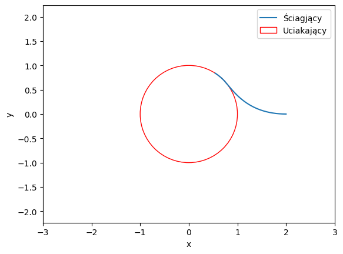

```python
x1,y1=pursuit_circle(0.5,1,2,0,0.001, 1000)
plt.plot(x1,y1,label='Ściagjący')
circle = plt.Circle((0, 0), 1, color='red', fill=False)
plt.gca().add_patch(circle)
plt.axis('equal')
plt.xlim(-3,3)
plt.ylim(-3,3)
plt.xlabel('x')
plt.ylabel('y')
plt.legend(['Ściagjący','Uciakający'])
plt.show()
```

1. Jeśli $k=1$ to dystans między „ścigającym”, a „uciekającym” dąży do $0$, lecz niegdy się nie dogonią

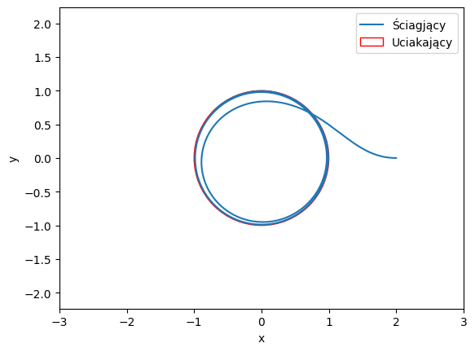

```python
x1,y1=pursuit_circle(1,1,2,0,0.001, 15000)
plt.plot(x1,y1,label='Ściagjący')
circle = plt.Circle((0, 0), 1, color='red', fill=False)
plt.gca().add_patch(circle)
plt.axis('equal')
plt.xlim(-3,3)
plt.ylim(-3,3)
plt.xlabel('x')
plt.ylabel('y')
plt.legend(['Ściagjący','Uciakający'])
plt.show()
```

1. Jeśli $k \geq 1$ oraz krzywa ma okrąg z środkiem $O$ oraz promień $R/k$ jako aymptotyczny okrąg, i oglegóść między „ścigającym” a „uciekającym” dąży do $R\sqrt{1-\displaystyle\frac{1}{k^2}}$

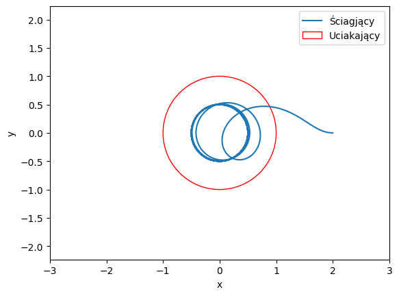

```python
x1,y1=pursuit_circle(2,1,2,0,0.001, 100000)
plt.plot(x1,y1,label='Ściagjący')
circle = plt.Circle((0, 0), 1, color='red', fill=False)
plt.gca().add_patch(circle)
plt.axis('equal')
plt.xlim(-3,3)
plt.ylim(-3,3)
plt.xlabel('x')
plt.ylabel('y')
plt.legend(['Ściagjący','Uciakający'])
plt.show()
```

#### D. Model zakładający, że „uciekający” porusza się po innych krzywych parametrycznych

##### a. Przypadek, w którym „uciekający” porusza się po sinusoidzie

Implementacja algorytmu w Pythonie

```python
def sinus(v,w,x0,y0,h):
    k=v/w
    x=[x0]
    y=[y0]
    t=0
    for i in range(10000):
        x.append(x[i]+h*k*w*(t-x[i])/(np.sqrt(((t-x[i])**2)+((np.sin(t)-y[i])**2))))
        y.append(y[i]+h*k*w*(np.sin(t)-y[i])/(np.sqrt(((t-x[i])**2)+((np.sin(t)-y[i])**2))))
        t+=h
    return x,y
```

Przypadek, w którym „ścigający” biegnie wolniej od „uciekającego” ($k<1$)

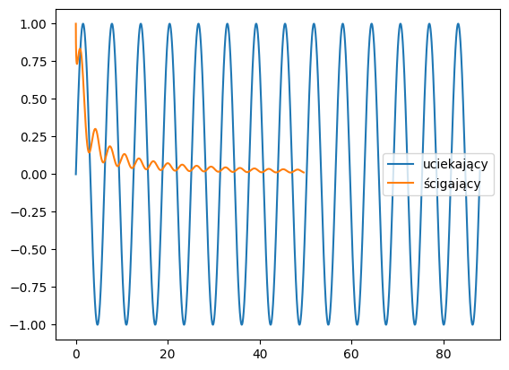

```python
x1,y1=sinus(0.5,1,0,1,0.01)
t=np.arange(0,88,0.01)
plt.plot(t,np.sin(t), label= "uciekający")
plt.plot(x1,y1, label = "ścigający")
plt.legend()
plt.show()
```

Przypadek, w którym „ścigający” i „uciekający” biegną z taką samą prędkością ($k=1$)

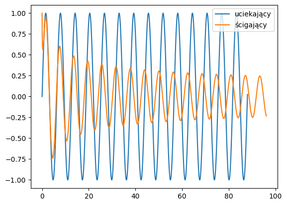

```python
x1,y1=sinus(1,1,0,1,0.01)
t=np.arange(0,88,0.01)
plt.plot(t,np.sin(t), label= "uciekający")
plt.plot(x1,y1, label = "ścigający")
plt.legend()
plt.show()
```

Przypadek, w którym „ścigający” porusza się szybciej od „uciekającego” ($k>1$)

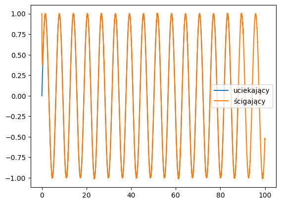

```python
x1,y1=sinus(2,1,0,1,0.01)
t=np.arange(0,88,0.01)
plt.plot(t,np.sin(t), label= "uciekający")
plt.plot(x1,y1, label = "ścigający")
plt.legend()
plt.show()
```

##### b. Przypadek, w którym „uciekający” porusza się po kardioidzie

Implementacja algorytmu w Pythonie

```python
def kardioida(v,w,x0,y0,h):
    k=v/w
    x=[x0]
    y=[y0]
    t=0
    for i in range(10000):
        x.append(x[i]+h*k*w*((2*np.cos(t)-np.cos(2*t))-x[i])/(np.sqrt((((2*np.cos(t)-np.cos(2*t))-x[i])**2)+(((2*np.sin(t)-np.sin(2*t))-y[i])**2))))
        y.append(y[i]+h*k*w*((2*np.sin(t)-np.sin(2*t))-y[i])/(np.sqrt((((2*np.cos(t)-np.cos(2*t))-x[i])**2)+(((2*np.sin(t)-np.sin(2*t))-y[i])**2))))
        t+=h
    return x,y
```

Przypadek, w którym „ścigający” biegnie wolniej od „uciekającego” ($k<1$)

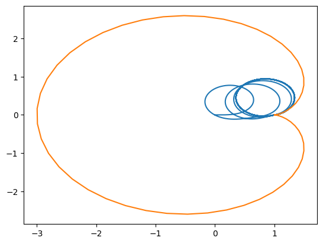

```python
x1,y1=kardioida(0.5,1,0,0,0.01)
t=np.arange(0,np.pi*2,0.1)
plt.plot(x1,y1)
plt.plot((2*np.cos(t)-np.cos(2*t)),(2*np.sin(t)-np.sin(2*t)))
plt.show()
```

Przypadek, w którym „ścigający” i „uciekający” biegną z taką samą prędkością ($k=1$)

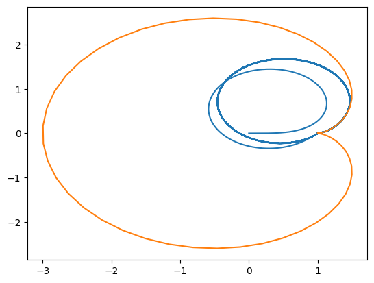

```python
x1,y1=kardioida(1,1,0,0,0.01)
t=np.arange(0,np.pi*2,0.1)
plt.plot(x1,y1)
plt.plot((2*np.cos(t)-np.cos(2*t)),(2*np.sin(t)-np.sin(2*t)))
plt.show()
```

Przypadek, w którym „ścigający” porusza się szybciej od "uciekającego" ($k>1$)

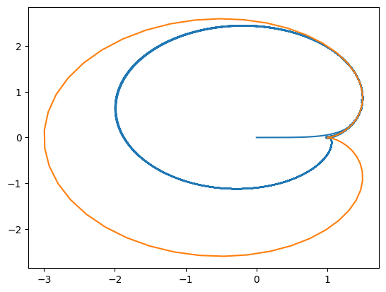

```python
x1,y1=kardioida(2,1,0,0,0.01)
t=np.arange(0,np.pi*2,0.1)
plt.plot(x1,y1)
plt.plot((2*np.cos(t)-np.cos(2*t)),(2*np.sin(t)-np.sin(2*t)))
plt.show()
```

#### E. Implementacja w przykładowych modelach trójwymairowych

##### a. Model zakładający, że tor „uciekającego” to heliksa

Implementacja algorytmu w Pythonie

```python
def helix(v,w,x0,y0,z0,h):
    k=v/w
    x=[x0]
    y=[y0]
    z=[z0]
    t=0
    for i in range(1000):
        x.append(x[i]+h*k*w*(np.cos(t)-x[i])/(np.sqrt(((np.cos(t)-x[i])**2)+((np.sin(t)-y[i])**2)+(t-z[i])**2)))
        y.append(y[i]+h*k*w*(np.sin(t)-y[i])/(np.sqrt(((np.cos(t)-x[i])**2)+((np.sin(t)-y[i])**2)+(t-z[i])**2)))
        z.append(z[i]+h*k*w*(t-z[i])/(np.sqrt(((np.cos(t)-x[i])**2)+((np.sin(t)-y[i])**2)+((t-z[i])**2))))
        t+=h
    return x,y,z
```

Przypadek, w którym „ścigający” biegnie wolniej od „uciekającego” ($k<1$)

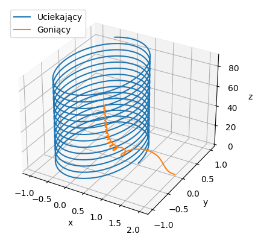

```python
x1,y1,z1=helix(0.5,1,2,0,0,0.1)
t=np.arange(0,90,0.01)
ax = plt.axes(projection='3d')
ax.plot3D(np.cos(t),np.sin(t),t,label='Uciekający')
ax.plot3D(x1,y1,z1,label='Goniący')
ax.set_xlabel('x')
ax.set_ylabel('y')
ax.set_zlabel('z')
ax.legend(loc='upper left')
plt.show()
```

Przypadek, w którym „ścigający” i „uciekający” biegną z taką samą prędkością ($k=1$)

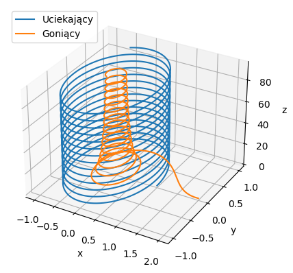

```python
x1,y1,z1=helix(1,1,2,0,0,0.1)
t=np.arange(0,90,0.01)
ax = plt.axes(projection='3d')
ax.plot3D(np.cos(t),np.sin(t),t,label='Uciekający')
ax.plot3D(x1,y1,z1,label='Goniący')
ax.set_xlabel('x')
ax.set_ylabel('y')
ax.set_zlabel('z')
ax.legend(loc='upper left')
plt.show()
```

Przypadek, w którym „ścigający” porusza się szybciej od „uciekającego” ($k>1$)

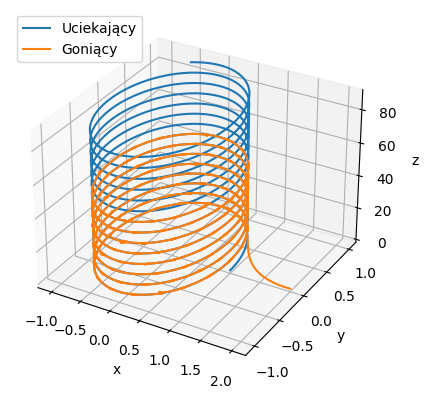

```python
x1,y1,z1=helix(2,1,2,0,0,0.05)
t=np.arange(0,90,0.01)
ax = plt.axes(projection='3d')
ax.plot3D(np.cos(t),np.sin(t),t,label='Uciekający')
ax.plot3D(x1,y1,z1,label='Goniący')
ax.set_xlabel('x')
ax.set_ylabel('y')
ax.set_zlabel('z')
ax.legend(loc='upper left')
plt.show()
```

### 4. Problem myszy

#### A. Wyjaśnienie problemu

Problem myszy to problem pościgu, w którym na rogach wielokątu formenego są rozmieszczone myszy. Każda mysz ściga swojego prawego "sąsiada" [6].

#### B. Przypadek z trzema myszami na trójkącie równobocznym [7]

Zacznijmy rozważanie problemu od 3 myszy znajdujących się na rogach trójkąta równobocznego. Zakładamy, że myszy poruszają się z taką samą predkością oraz że zachowują się symetrycznie. Każda mysz goni najbiższe zwierzę po prawej stronie.

Niech $M_1(t)=\left(x_1(t),y_1(t)\right)$ będzie pozycją 1. myszy w czasie $t \geq 0$. Zakładamy, że jej pozycja początkowa to $P_1=(0,0)$, przy czym $M_1(0)=P_1$. W takim sam sposób oznaczamy pozycję 2. myszy przez $M_2(t)$ oraz wybieramy warunki początkowe $M_2(0)=(1,0)=P_2$. Podobnie za $M_3(t)$ przyjmujemy pozycję 3. myszy z warunkiem początkowym $M_3(0)=\left(\frac{1}{2}, \frac{\sqrt{3}}{2}\right)= P_3$.

$M_2(t)$ możemy zapisać za pomocą rotacji $M_1(t)$ o kąt $\frac{2\pi}{3}$ wokół punktu $(0,0)$ i translacji o wektor $\overrightarrow{P_1P_2}$, zatem $$ \begin{equation} \begin{split} (x_2,y_2) & = T_{\binom{1}{0}}\left( R_{\frac{2}{3}\pi} (x_1, y_1) \right) \\ & = T_{\binom{1}{0}} (x_1 \cos{\frac{2}{3}\pi} - y_1\sin{\frac{2}{3}\pi}, x_1 \sin{\frac{2}{3}\pi} + y_1 \cos{\frac{2}{3}\pi} ) \\ & = (-\frac{1}{2}x_1+\frac{\sqrt{3}}{2}y_1+1, \frac{\sqrt{3}}{2}-\frac{1}{2}y_1), \end{split} \end{equation} $$ gdzie $R_{\varphi}$ oznacza rotacje o kąt $\varphi$ i $T_{\vec{v}}$ definiuje się jako translacje o wektor $\vec{v}$.

Przez $\overrightarrow{v_1}(t)$ oznaczmy $\overrightarrow{M_1M_2}(t)$, co reprezentuje kierunek ruchu 1. myszy (goniącej 2. mysz) w czasie $t\leq 0$, co jest równoznaczne z styczną do ścieżki ruchu 1. myszy w $M_1(t)$. Zatem jego gradient to gradient ścieźki M_1(t): $$ \frac{\mathrm{y_1}}{\mathrm{x_1}} = \frac{\Delta y_1}{\Delta x_1} = \frac{y_2(t)-y_1(t)}{x_2(t)-x_1(t)} = \frac{ \frac{\sqrt{3}}{2} x_1(t) - \frac{3}{2} y_1(t)}{ 1 = \frac{3}{2} x_1(t) - \frac{\sqrt{3}}{2} y_1(t)}. $$

Dalej zauważamy, że $$ \frac{\mathrm{d}y_1}{\mathrm{d}x_1}= \frac{\frac{\mathrm{d}y_1}{\mathrm{d}t}}{\frac{\mathrm{d}x_1}{\mathrm{d}t}} = \frac{ \frac{\sqrt{3}}{2} x_1(t) - \frac{3}{2}y_1(t)}{ 1-\frac{3}{2}x_1(t) - \frac{\sqrt{3}}{2} y_1(t) }, $$ zatem rozwiązanie można otrzymać po przez rozwiązywanie poiższego układu równań $$ \begin{cases} \frac{\mathrm{d}y_1}{\mathrm{d}t} = \frac{\sqrt{3}}{2}x_1(t)-\frac{3}{2}y_1 (t),\\ \frac{\mathrm{d}x_1}{\mathrm{d}t} = 1 - \frac{3}{2}x_1(t)-\frac{\sqrt{3}}{2}y_1 (t),\\ \end{cases} $$ który jest układem liniowych równań różniczkowych pierwszego rzędu.

#### C. Implementacja problemu w Pythonie

##### a. Model z trzema myszami

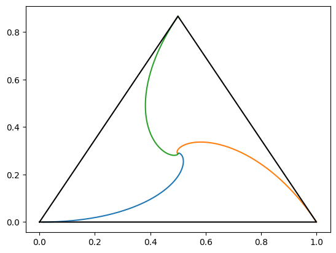

```python
def pursuit_mice3(h,x0,y0):
    y=[y0]
    x=[x0]
    t=0
    for i in range(10000):
        y.append(y[i]+h*((np.sqrt(3)/2)*x[i]-((3/2)*y[i])))
        x.append(x[i]+h*(1-(3/2)*x[i]-((np.sqrt(3)/2)*y[i])))
        t=t+h

    return x,y

x1,y1=pursuit_mice3(0.01,0.01,0)
x2,y2=pursuit_mice3(0.01,1,0)
x3,y3=pursuit_mice3(0.01,0.5,np.sqrt(3)/2)

xs = [0,1,0.5,0]
ys=[0,0,np.sqrt(3)/2,0]
plt.plot(x1,y1)
plt.plot(x2,y2)
plt.plot(x3,y3)
plt.plot(xs,ys,color="black")
plt.show()
```

##### b. Model z czterema myszami

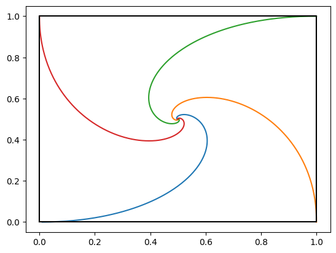

```python
def pursuit_mice4(h,x0,y0):
    y=[y0]
    x=[x0]
    t=0
    for i in range(1000):
        y.append(y[i]+h*(x[i]-y[i]))
        x.append(x[i]+h*(1-x[i]-y[i]))
        t=t+h

    return x,y

x1,y1=pursuit_mice4(0.01,0.01,0)
x2,y2=pursuit_mice4(0.01,1,0)
x3,y3=pursuit_mice4(0.01,1,1)
x4,y4=pursuit_mice4(0.01,0,1)

xs = [0,1,1,0,0]
ys=[0,0,1,1,0]
plt.plot(x1,y1)
plt.plot(x2,y2)
plt.plot(x3,y3)
plt.plot(x4,y4)
plt.plot(xs,ys,color="black")
plt.show()
```

##### c. Model z pięcioma myszami

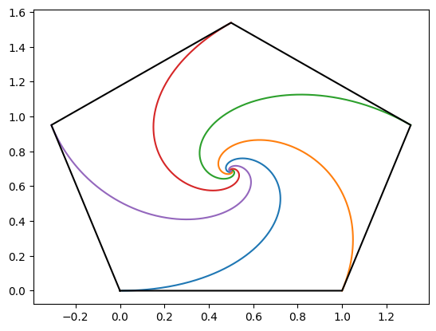

```python
def pursuit_mice5(h,x0,y0):
    y=[y0]
    x=[x0]
    t=0
    for i in range(1000):
        y.append(y[i]+h*(x[i]*np.sin(2*np.pi/5)+y[i]*(np.cos(2*np.pi/5)-1)))
        x.append(x[i]+h*(x[i]*(np.cos(2*np.pi/5)-1)-y[i]*np.sin(2*np.pi/5)+1))
        t+=h
    return x,y

x1,y1=pursuit_mice5(0.01,0.01,0)
x2,y2=pursuit_mice5(0.01,1,0)
x3,y3=pursuit_mice5(0.01,1+np.cos(2*np.pi/5),np.sin(2*np.pi/5))
x4,y4=pursuit_mice5(0.01,0.5,np.sin(2*np.pi/5)+np.cos(3*np.pi/10))
x5,y5=pursuit_mice5(0.01,-np.cos(2*np.pi/5),np.sin(2*np.pi/5))

xs = [0,1,1+np.cos(2*np.pi/5),0.5,-np.cos(2*np.pi/5),0]
ys=[0,0,np.sin(2*np.pi/5),np.sin(2*np.pi/5)+np.cos(3*np.pi/10),np.sin(2*np.pi/5),0]
plt.plot(x1,y1)
plt.plot(x2,y2)
plt.plot(x3,y3)
plt.plot(x4,y4)
plt.plot(x5,y5)

plt.plot(xs,ys,color="black")
plt.show()
```

##### d. Model z sześcioma myszami

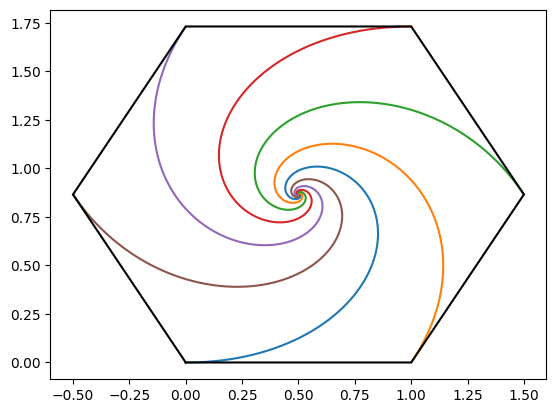

```python
def pursuit_mice6(h,x0,y0):
    y=[y0]
    x=[x0]
    t=0
    for i in range(1000):
        y.append(y[i]+h*(x[i]*np.sin(2*np.pi/6)+y[i]*(np.cos(2*np.pi/6)-1)))
        x.append(x[i]+h*(x[i]*(np.cos(2*np.pi/6)-1)-y[i]*np.sin(2*np.pi/6)+1))
        t+=h
    return x,y

x1,y1=pursuit_mice6(0.01,0.01,0)
x2,y2=pursuit_mice6(0.01,1,0)
x3,y3=pursuit_mice6(0.01,1.5,np.sqrt(3)/2)
x4,y4=pursuit_mice6(0.01,1,np.sqrt(3))
x5,y5=pursuit_mice6(0.01,0,np.sqrt(3))
x6,y6=pursuit_mice6(0.01,-0.5,np.sqrt(3)/2)

xs = [0,1,1.5,1,0,-0.5,0]
ys=[0,0,np.sqrt(3)/2,np.sqrt(3),np.sqrt(3),np.sqrt(3)/2,0]
plt.plot(x1,y1)
plt.plot(x2,y2)
plt.plot(x3,y3)
plt.plot(x4,y4)
plt.plot(x5,y5)
plt.plot(x6,y6)
plt.plot(xs,ys,color="black")
plt.show()
```

### 6. Bibliografia

[1] MALACKA, Z.: *Pursuit Curves and Ordinary Differential Equations.*, "Communications" – Scientific Letters of the University of Zilina, nr. 1, 2012, s.66-68

[2] BOOLE G. A.: *Treatise on differential equations*, Cambridge, Macmillan and Co., 1859, s. 24

[3] Weisstein E.W., *Pursuit Curve*, "MathWorld--A Wolfram Web Resource" [online], https://mathworld.wolfram.com/PursuitCurve.html [dostęp 08-01-2023]

[4] LLYOD M. : *Pursuit Curves*, "Academic Forum" Henderson State University Arkadelphia, Arkansas, nr 24, 2006-07, s. 4-10

[5] FERRÉOL R.: *Pursuit Curve*, "Mathcurve" [online], https://mathcurve.com/courbes2d.gb/poursuite/poursuite.shtml [dostep 08-01-2023]

[6] Weisstein E. W.: *Mice Problem*, "MathWorld--A Wolfram Web Resource" [online], https://mathworld.wolfram.com/MiceProblem.html [dostęp 08-01-2023]

[7] JANCZEWSKI A.T.: *From Mice Pursuit Problem to Laplace transform*, Politechnika Wrocławska, 2014